# Data Storytelling Project: Employee Turnover Analysis

Grace Lippert

2026-06-02

# 1 Introduction

## 1.1 Background and Dataset Information

The dataset used for this analysis contains 1129 observations and 16 variables and comes from the UCI-Machine Learning Repository. The variables contain information regarding employee gender, age, wage type, method of travel to work, source of hire, and big five personality traits. The big five personality traits are openness to experience, conscientiousness, extroversion, agreeableness, and neuroticism. A complete table of the variables is listed below:

```r
data_dictionary <- tribble(
  ~Variable_Name,    ~Description,                                                                        ~Variable_Type,
  "[stag]",          "[Experience (some kind of standardized stay with the organization)]",               "[Numeric]",
  "[event]",         "[Turnover event (1 = left position, 0 = stayed in position)]",                      "[Numeric (Binary)]",
  "[gender]",        "[gender (f=female, m=male)]",                                                       "[Categorical]",
  "[age]",           "[Age of employee (years)]",                                                         "[Numeric]",
  "[industry]",      "[Industry type (e.g., Building, Agriculture, Banks, State, etc.)]",                 "[Categorical]",
  "[profession]",    "[Profession type (e.g., Teaching, PR, Engineer, Law, etc.)]",                       "[Categorical]",
  "[traffic]",       "[Pipeline that brought candidate to the company (e.g., advert, friends, etc.)]",    "[Categorical]",
  "[coach]",         "[Presence of coach on probation (yes, no, my head)]",                               "[Categorical]",
  "[head_gender]",   "[Gender of direct head (f=female, m=male)]",                                        "[Categorical]",
  "[greywage]",      "[The salary does not seem to tax the authorities (white, grey)]",                   "[Categorical]",
  "[way]",           "[How an employee gets to the workplace (bus, car, foot)]",                          "[Categorical]",
  "[extroversion]",  "[Outgoing/Energetic vs. Solitary/Reserved (scored out of 10)]",                     "[Numeric]",
  "[independ]",      "[Agreeableness - Friendly/Compassionate vs. Critical/Rational (out of 10)]",        "[Numeric]",
  "[selfcontrol]",   "[Conscientiousness - Efficient/Organized vs. Extravagant/Careless (out of 10)]",    "[Numeric]",
  "[anxiety]",       "[Neuroticism - Sensitive/Nervous vs. Resilient/Confident (out of 10)]",             "[Numeric]",
  "[novator]",       "[Openness to experience - Inventive/Curious vs. Consistent/Cautious (out of 10)]",  "[Numeric]",

)

datatable(
  data_dictionary,
  caption = "Table 1: Variable definitions and types for the analysis dataset",
  rownames = FALSE,
  options = list(pageLength = 10, dom = 'tip')
)
```

| Variable_Name | Description | Variable_Type |
| --- | --- | --- |
| [stag] | [Experience (some kind of standardized stay with the organization)] | [Numeric] |
| [event] | [Turnover event (1 = left position, 0 = stayed in position)] | [Numeric (Binary)] |
| [gender] | [gender (f=female, m=male)] | [Categorical] |
| [age] | [Age of employee (years)] | [Numeric] |
| [industry] | [Industry type (e.g., Building, Agriculture, Banks, State, etc.)] | [Categorical] |
| [profession] | [Profession type (e.g., Teaching, PR, Engineer, Law, etc.)] | [Categorical] |
| [traffic] | [Pipeline that brought candidate to the company (e.g., advert, friends, etc.)] | [Categorical] |
| [coach] | [Presence of coach on probation (yes, no, my head)] | [Categorical] |
| [head_gender] | [Gender of direct head (f=female, m=male)] | [Categorical] |
| [greywage] | [The salary does not seem to tax the authorities (white, grey)] | [Categorical] |

[output cut: 6 more lines]

## 1.2 Business Questions and Hypotheses:

This dataset will be used to answer the following set of practical questions:

**Question 1:** Which industries and professions experience the most employee turnover?

**Question 2:** Is an employee’s rating on the Big5 personality test scale useful in predicting employee turnover?

**Question 3:** Is an employee’s age, gender, or experience useful in predicting employee turnover?

The hypotheses for these questions (based on current understanding before analysis) are listed below:

**Hypothesis 1:** Industries with lower wages and limited career advancement (e.g. Retail) experience higher employee turnover. Similarly, professions with lower wages and high emotional burnout (e.g. Teaching) experience higher employee turnover.

**Hypotheses 2:** Employees who score higher on extroversion, agreeableness, and conscientiousness as well as score lower on neuroticism and openness to experience are less likely leave their position.

**Hypotheses 3:** Employees that are older and have more experience in their current position are less likely to leave their position.

# 2 Data Quality, Distribution, and Relationship Assessment

## 2.1 Missing Values and Reformatting

```r
setwd("C:/Users/grace/OneDrive/Stat Graduate Work/STA553 - Data Visualization")
turnover <- read.csv("turnover-data-set.csv")
turnover$event <- factor(turnover$event, levels = c(0,1), labels = c("Stay", "Left"))
```

## 2.2 Distribution Analysis

We will begin by examining the distributions of the numeric variables in the dataset. Understanding the shape, spread, and skewness of these variables can help us identify unusual patterns and outliers that may need to be taken into account when considering future modeling.

The below figure displays the distributions of the variables ‘[stag],’ ‘[age],’ and the employee scores of the Big5 personality scores.

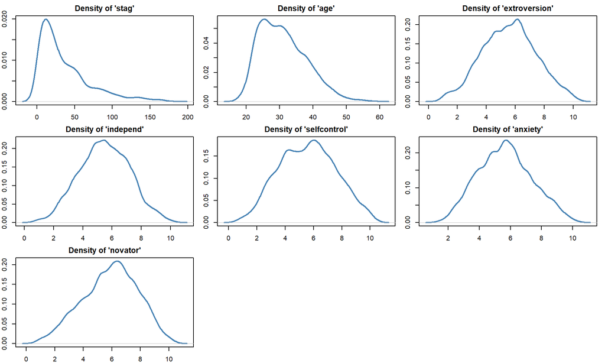

```r
par(mfrow = c(3, 3),
 mar = c(2, 2, 2, 1))

plot(density(turnover$stag), col ="steelblue", lwd=2, main="Density of 'stag'", xlab="")

plot(density(turnover$age), col ="steelblue", lwd=2, main="Density of 'age'", xlab="")

plot(density(turnover$extraversion), col ="steelblue", lwd=2, main="Density of 'extroversion'", xlab="")

plot(density(turnover$independ), col ="steelblue", lwd=2, main="Density of 'independ'", xlab="")

plot(density(turnover$selfcontrol), col ="steelblue", lwd=2, main="Density of 'selfcontrol'", xlab="")

plot(density(turnover$anxiety), col ="steelblue", lwd=2, main="Density of 'anxiety'", xlab="")

plot(density(turnover$novator), col ="steelblue", lwd=2, main="Density of 'novator'", xlab="")

par(mfrow = c(1,1))
```

```r
par(mar = c(5.1, 4.1, 4.1, 2.1))
```

Employee experience (‘[stag]’) appears to be a right-skewed distribution indicating that relatively few employees remained within their position for extended periods of time. Age also appears to have a (slight) right-skew, meaning that more of the employees within this dataset were concentrated in early-to-middle adulthood. Finally, each of the Big5 personality score distributions is roughly symmetric and centered near the middle of the 10-point scale. This indicates that extreme scores are atypical within this dataset.

Next we can consider the frequency distributions of the categorical variables. The for ‘[event],’ ‘[gender],’ ‘[industry],’ ‘[profession],’ ‘[traffic],’ ‘[coach],’ ‘[head_gender],’ ‘[greywage],’ and ‘[way]’ are located below.

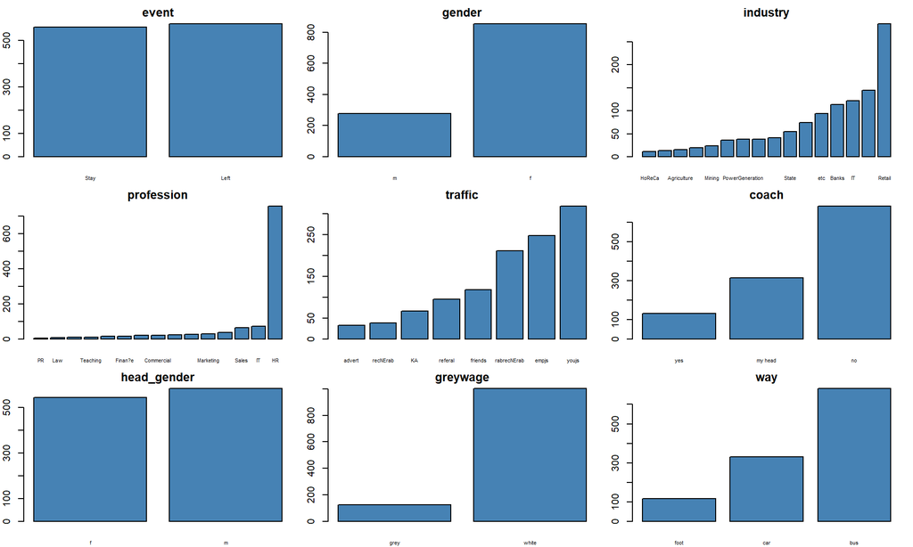

```r
par(mfrow = c(3, 3),
 mar = c(2, 2, 2, 1))

barplot(sort(table(turnover$event)), main="event", col="steelblue", cex.names=0.5)

barplot(sort(table(turnover$gender)), main="gender", col="steelblue", cex.names=0.5)

barplot(sort(table(turnover$industry)), main="industry", col="steelblue", cex.names=0.5)

barplot(sort(table(turnover$profession)), main="profession", col="steelblue", cex.names=0.5)

barplot(sort(table(turnover$traffic)), main="traffic", col="steelblue", cex.names=0.5)

barplot(sort(table(turnover$coach)), main="coach", col="steelblue", cex.names=0.5)

barplot(sort(table(turnover$head_gender)), main="head_gender", col="steelblue", cex.names=0.5)

barplot(sort(table(turnover$greywage)), main="greywage", col="steelblue", cex.names=0.5)

barplot(sort(table(turnover$way)), main="way", col="steelblue", cex.names=0.5)
```

```r
par(mfrow = c(1,1))
par(mar = c(5.1, 4.1, 4.1, 2.1))
```

The target variable ‘[event]’ appears to be roughly equal across both categories. Meanwhile variables like ‘[gender],’ ‘[industry],’ ‘[traffic],’ ‘[coach],’ and ‘[greywage]’ show significant variation across categories. Notably, categories like ‘Retail’ for industry and ‘HR’ for profession are much greater than other categories within their group. Finally, ‘[head_gender],’ like ‘[event]’ is roughly symmetric across both categories.

## 2.3 Correlation between Numeric Variables

Finally, before assessing our questions and hypotheses, we will briefly consider the correlations between our numeric variables. The correlations between ‘[stag],’ ‘[age],’ and employee Big5 scores are represented in the figure below:

```r
par(mar = c(5, 10, 4, 2))
num_vars <- turnover[, c("stag", "age", "extraversion", "independ", "selfcontrol", "anxiety", "novator")]
cor_mat <- cor(num_vars)
round(cor_mat, 2)
```

```
##               stag   age extraversion independ selfcontrol anxiety novator
## stag          1.00 -0.20        -0.09     0.00        0.08    0.01   -0.04
## age          -0.20  1.00        -0.15     0.06        0.04    0.06    0.04
## extraversion -0.09 -0.15         1.00    -0.20       -0.54   -0.14    0.30
## independ      0.00  0.06        -0.20     1.00       -0.17   -0.43    0.02
## selfcontrol   0.08  0.04        -0.54    -0.17        1.00   -0.11   -0.57
## anxiety       0.01  0.06        -0.14    -0.43       -0.11    1.00    0.25
## novator      -0.04  0.04         0.30     0.02       -0.57    0.25    1.00
```

[figure not shown]

```r
cor_mat <- cor(num_vars)

n <- ncol(cor_mat)

cols <- colorRampPalette(c("steelblue", "red"))(100)

plot(1:n, 1:n,
     type = "n",
     xlim = c(0.5, n + 0.5),
     ylim = c(0.5, n + 0.5),
     xaxt = "n",
     yaxt = "n",
     xlab = "",
     ylab = "",
     asp = 1,
     main = "Correlation Matrix")

axis(1, at = 1:n, labels = colnames(cor_mat), las = 2)
axis(2, at = 1:n, labels = colnames(cor_mat), las = 2)

for(i in 1:n){
  for(j in 1:n){
    r <- cor_mat[i,j]
    idx <- round((r + 1) / 2 * 99) + 1

    rect(i - 0.5, n-j+0.5,
         i + 0.5, n-j+1.5,
         col = cols[idx],
         border = "white")

    text(i,
         n-j+1,
         labels = sprintf("%.2f", r),
         col="white",
         font=2,
         cex = 0.8)
  }
}
```

Most numeric variables exhibited weak correlations, which indicates that the variables measure distinct employee characteristics. Some of the strongest correlations occurred among the Big5 personality variables. The variables ‘[selfcontrol]’ and ‘[novator]’ had a correlation of (r= -0.57) and ‘[extraversion]’ and ‘[selfcontrol]’ had a correlation of (r = -0.54). Since no pair of variables demonstrated a correlation of greater than 0.60 or less than -0.60, substantial collinearity or multicollinearity does not appear to be present within the dataset.

# 3 Which industries and professions experience the greatest employee turnover?

To address **Question 1**, we will calculate and graph turnover rates within each industry and profession.

## 3.1 Industry Employee Turnover

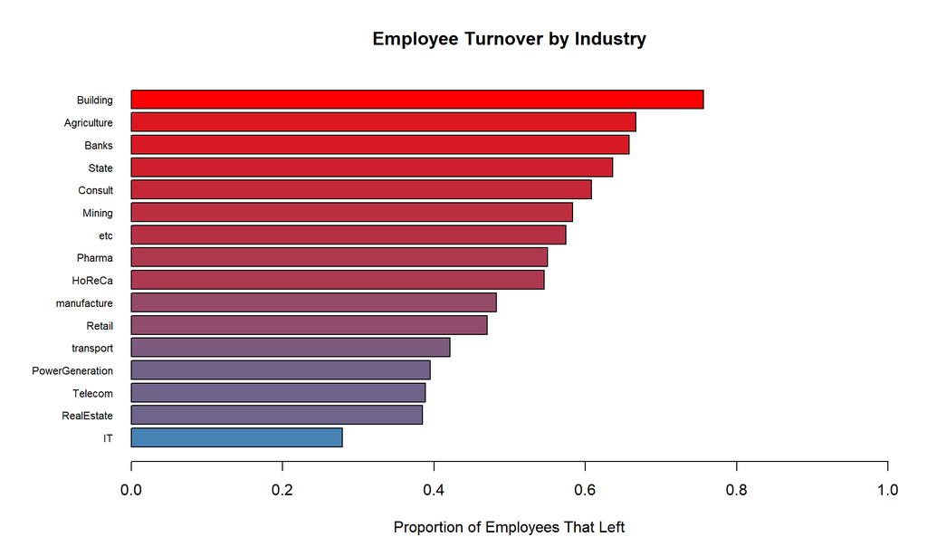

```r
par(mar = c(5.1, 7.1, 4.1, 2.1))
tab1 <- table(turnover$industry, turnover$event)

left_rate1 <- sort(tab1[, "Left"] /rowSums(tab1))

color_index1 <- cut(left_rate1, breaks = 100, labels = FALSE)

palette <- colorRampPalette(c("steelblue", "red"))(100)

barplot(left_rate1, horiz=TRUE, xlim=c(0,1),
        main="Employee Turnover by Industry",
        xlab="Proportion of Employees That Left", cex.names=0.7,
        col=palette[color_index1],
        las=1)
```

```r
par(mar = c(5.1, 4.1, 4.1, 2.1))
```

The above figure displays employee turnover rates across industries. The color gradient highlights employee turnover intensity, with red shades corresponding to higher turnover rates. These results indicate that ‘Building’ had a notably higher employee turnover rate than other categories, with ‘Agriculture,’ ‘Banks,’ and ‘State’ also having fairly high employee turnover rates. Interestingly, ‘IT’ had a notably lower employee turnover rate than other categories. The pattern above provides evidence that certain industries experience greater turnover than others.

## 3.2 Profession Employee Turnover

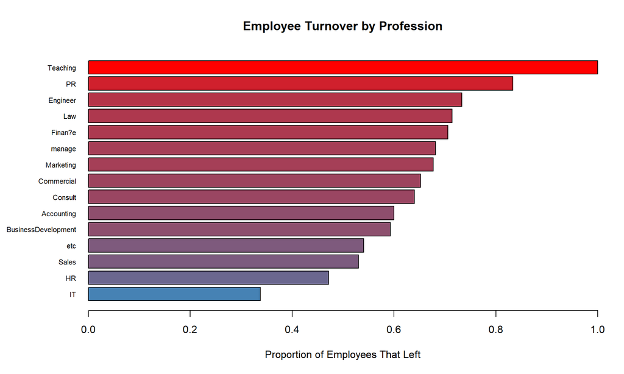

```r
par(mar = c(5.1, 7.1, 4.1, 2.1))
tab2 <- table(turnover$profession, turnover$event)

left_rate2 <- sort(tab2[, "Left"] /rowSums(tab2))

color_index2 <- cut(left_rate2, breaks = 100, labels = FALSE)

palette <- colorRampPalette(c("steelblue", "red"))(100)

barplot(left_rate2, horiz=TRUE, xlim=c(0,1),
        main="Employee Turnover by Profession",
        xlab="Proportion of Employees That Left", cex.names=0.7,
        col=palette[color_index2],
        las=1)
```

```r
par(mar = c(5.1, 4.1, 4.1, 2.1))
```

The above figure displays turnover rates by profession. Once again, the color gradient highlights employee turnover intensity, with red shades corresponding to higher turnover rates. These results indicate that ‘Teaching’ had a notably higher employee turnover rate than other categories, with ‘PR,’ ‘Engineer,’ and ‘Law’ also having fairly high employee turnover rates. Similarly to before, ‘IT’ had a notably lower employee turnover rate than other categories. The pattern above provides evidence that certain professions experience greater turnover than others.

# 4 Is an employee’s Big5 personality test scale useful in predicting employee turnover?

To investigate whether or not Big5 personality scores are associated with, and a potential predictor of, employee turnover, density distributions of the Big5 personality traits of employees who left their positions and employees who stayed in their positions are listed below. Specifically, distributions of the variables ‘[extroversion],’ ‘[independ],’ ‘[selfcontrol],’ ‘[anxiety],’ and ‘[novator]’ are present.

[figure not shown]

```r
plot(density(turnover$extraversion[turnover$event=="Left"]), col="steelblue", lwd=2, lty=2, main="Distribution of 'Extraversion' by Employment Event (Stayed or Left)", xlab="'Extraversion' Score")

lines(density(turnover$extraversion[turnover$event=="Stay"]), col="red", lwd=2)

legend("topright", legend=c("Stayed", "Left"),
       col=c("steelblue", "red"), lwd=2, lty=c(2,1), cex=0.75)
```

[figure not shown]

```r
plot(density(turnover$independ[turnover$event=="Left"]), col="steelblue", lwd=2, lty=2, main="Distribution of 'Independ' by Employment Event (Stayed or Left)", xlab="'Independ' Score")

lines(density(turnover$independ[turnover$event=="Stay"]), col="red", lwd=2)

legend("topright", legend=c("Stayed", "Left"),
       col=c("steelblue", "red"), lwd=2, lty=c(2,1), cex=0.75)
```

[figure not shown]

```r
plot(density(turnover$selfcontrol[turnover$event=="Left"]), col="steelblue", lwd=2, lty=2, main="Distribution of 'SelfControl' by Employment Event (Stayed or Left)", xlab="'SelfControl' Score")

lines(density(turnover$selfcontrol[turnover$event=="Stay"]), col="red", lwd=2)

legend("topright", legend=c("Stayed", "Left"),
       col=c("steelblue", "red"), lwd=2, lty=c(2,1), cex=0.75)
```

[figure not shown]

```r
plot(density(turnover$anxiety[turnover$event=="Left"]), col="steelblue", lwd=2, lty=2, main="Distribution of 'Anxiety' by Employment Event (Stayed or Left)", xlab="'Anxiety' Score")

lines(density(turnover$anxiety[turnover$event=="Stay"]), col="red", lwd=2)

legend("topright", legend=c("Stayed", "Left"),
       col=c("steelblue", "red"), lwd=2, lty=c(2,1), cex=0.75)
```

[figure not shown]

```r
plot(density(turnover$novator[turnover$event=="Left"]), col="steelblue", lwd=2, lty=2, main="Distribution of 'Novator' by Employment Event (Stayed or Left)", xlab="'Novator' Score")

lines(density(turnover$novator[turnover$event=="Stay"]), col="red", lwd=2)

legend("topright", legend=c("Stayed", "Left"),
       col=c("steelblue", "red"), lwd=2, lty=c(2,1), cex=0.75)
```

The above figures show substantial overlap between the distributions of employees who stayed and employees who left across all Big5 personality traits. While minor differences in the shapes and locations of the density curves are present, these differences are relatively small and do not suggest a meaningful difference between the two groups. In each case, employees who left their positions exhibited Big5 personality score distributions that were very similar to those who remained at their positions.

# 5 Is an employee’s gender, age, or experience useful in predicting employee turnover?

To address **Question 3**, we will examine turnover patterns across the demographic characteristics of gender, age, and experience. Gender will be evaluated by considering the proportion of turnover for each gender, and age and organizational experience will be evaluated using density plots.

## 5.1 Employee Gender by Employee Turnover

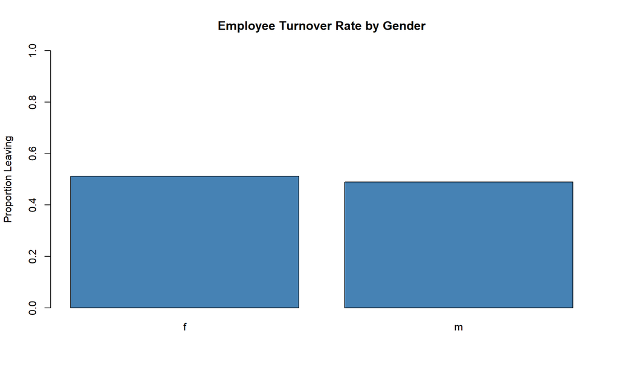

```r
tab4 <- table(turnover$gender, turnover$event)
left_rate4 <- tab4[, "Left"] / rowSums(tab4)
barplot(left_rate4, col = "steelblue", main = "Employee Turnover Rate by Gender", ylab = "Proportion Leaving", ylim = c(0, 1))
```

The above figure shows the proportion of employees who left their positions within each gender category. The similar turnover rates suggest that gender is not strongly associated with turnover.

## 5.2 Employee Age by Employee Turnover

[figure not shown]

```r
plot(density(turnover$age[turnover$event=="Left"]), col="steelblue", lwd=2, lty=2, main="Distribution of 'Age' by Employment Event (Stayed or Left)", xlab="Age")

lines(density(turnover$age[turnover$event=="Stay"]), col="red", lwd=2)

legend("topright", legend=c("Stayed", "Left"),
       col=c("steelblue", "red"), lwd=2, lty=c(2,1), cex=0.75)
```

## 5.3 Employee Experience by Employee Turnover

[figure not shown]

```r
plot(density(turnover$stag[turnover$event=="Left"]), col="steelblue", lwd=2, lty=2, main="Distribution of 'Stag' by Employment Event (Stayed or Left)", xlab="Stag")

lines(density(turnover$stag[turnover$event=="Stay"]), col="red", lwd=2)

legend("topright", legend=c("Stayed", "Left"),
       col=c("steelblue", "red"), lwd=2, lty=c(2,1), cex=0.75)
```

The above figure compares the experience ([‘stag’]) distribution of employees who stayed and employees who left. Considering that there is no meaningful separation between the two density curves, we do not have evidence to suggest that experience is useful in predicting turnover.

# 6 Conclusion and Recommendations

The purpose of this analysis was to identify factors associated with employee turnover and determine whether occupational factors, personality traits, or demographic characteristics could be useful in predicting whether or not employees will leave their positions. Briefly, we will reconsider our questions and hypotheses:

## 6.1 Questions:

**Question 1:** Which industries and professions experience the most turnover?

**Question 2:**: Is an employee’s rating on the Big5 personality test scale useful in predicting turnover?

**Question3:** Is an employee’s age, gender, or experience useful in predicting turnover?

## 6.2 Hypotheses:

**Hypothesis 1:** Industries with lower wages and limited career advancement (e.g. Retail) experience higher employee turnover. Similarly, professions with lower wages and high emotional burnout (e.g. Teaching) experience higher employee turnover.

**Hypotheses 2:** Employees that score more highly for extroversion, agreeableness, and conscientiousness as well as score lower for neuroticism and openness to experience are less likely leave their position.

**Hypotheses 3:** Employees that are older and have more experience in their current position are less likely to leave their position.

Addressing our first question, the results suggest that industry and profession appear to be the factors most strongly associated with turnover within this dataset. Among industries, building, agriculture, banking, and state-related organizations experienced relatively high turnover, where IT experienced the lowest turnover. Similarly, teaching, public relations, engineering, and law showed the highest turnover rates among professions, while IT-related professions once again demonstrated the lowest employee turnover rate. This finding is partially consistent with the initial hypothesis that professions associated with emotional burnout and low wages experience higher employee turnover.